# Bayesian Methods for CDH dataset

Zanis Fang, UID: ZF2213

3/17/2019

### Data cleaning

**Cases selection** Death cases were removed because it would not reasonable to impute their follow-up data. After removal of death cases, “dead”, “discharge”, “SampleID”, “dc_dead_age”, “dc_alive_age” were also removed.

**Structural Imputation** NA’s in “gu_anomaly”, “clp”, “sk_anomalies”, “bps”, “ccam” can be imputed with 0 as long as “sys” is not NA. Since they added up to the number in “sys”.

Making categorical variables factors for downstream anaylsis. “sys”, “apgar_1”, “apgar_5” remains continuous since they are ordinal.

**Missing value imputation using EM algorithm**

Use expectation-maximization (EM) algorithm to impute missing values. Setting 3 underlying latent components.

**Scaling and centering the continuous variables**

Using square-root unit variance as scaling parameters. Centering around zero.

### Factor Analysis

FAMD (Factor Analysis for Mixed Data) is a principal component method dedicated to explore data with both continuous and categorical variables. It can be seen roughly as a mixed between PCA and MCA (multiple correspondence analysis).

Since the dataset contains a lot of categorical variables, it would be better to use factor analysis.

**Factor analysis results**

Eigenvalues:

|  | eigenvalue | percentage of variance | cumulative percentage of variance |
| --- | --- | --- | --- |
| comp 1 | 18.229916 | 23.675216 | 23.67522 |
| comp 2 | 9.171012 | 11.910405 | 35.58562 |
| comp 3 | 6.028826 | 7.829644 | 43.41526 |
| comp 4 | 3.208283 | 4.166601 | 47.58187 |
| comp 5 | 2.251688 | 2.924270 | 50.50614 |

Variables contribute most to the three dimensions are plotted and listed.

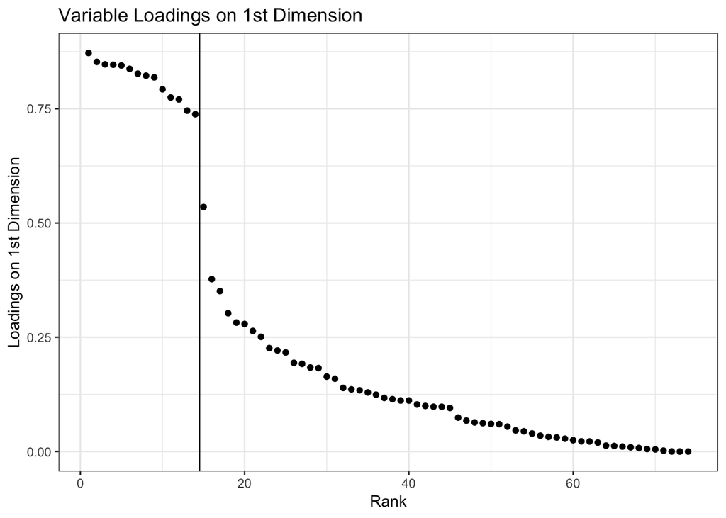

| variable | Dim.1 |
| --- | --- |
| da_lang_composite_score | 0.8471098 |
| da_cog_composite_score | 0.8463225 |
| da_mot_composite_score | 0.8267463 |
| vabs_com_stand_score | 0.7745699 |
| vabs_dai_liv_stand_score | 0.7703140 |
| vabs_soc_stand_score | 0.7457965 |
| vabs_mot_stand_score | 0.7925502 |
| vabs_adabehcomstand | 0.8446596 |
| crf7_da_fsiq_composite | 0.8372675 |
| crf7_vabs_com_stand_score | 0.8186371 |
| crf7_vabs_dai_liv_stand_score | 0.8524992 |
| crf7_vabs_soc_stand_score | 0.7380446 |
| crf7_vabs_mot_stand_score | 0.8223519 |
| crf7_vabs_adabehcomstand | 0.8720730 |

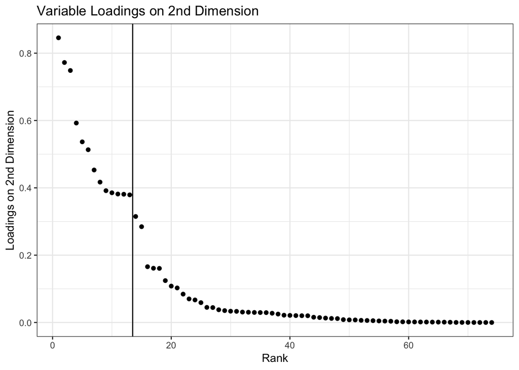

| variable | Dim.2 |
| --- | --- |
| wt_z_birth | 0.3815969 |
| ht_z_birth | 0.3852982 |
| hc_z_birth | 0.3791576 |
| waz_2yr | 0.5366035 |
| headcz_2yr | 0.5132322 |
| whz_2yr | 0.5925212 |
| da_age | 0.3809718 |
| waz_5yr | 0.8456763 |
| haz_5yr | 0.7485531 |
| whz_5yr | 0.4529908 |
| crf7_da_age | 0.7722696 |
| crf7_age_at_vine_ii_eval | 0.4170226 |
| gender | 0.3915410 |

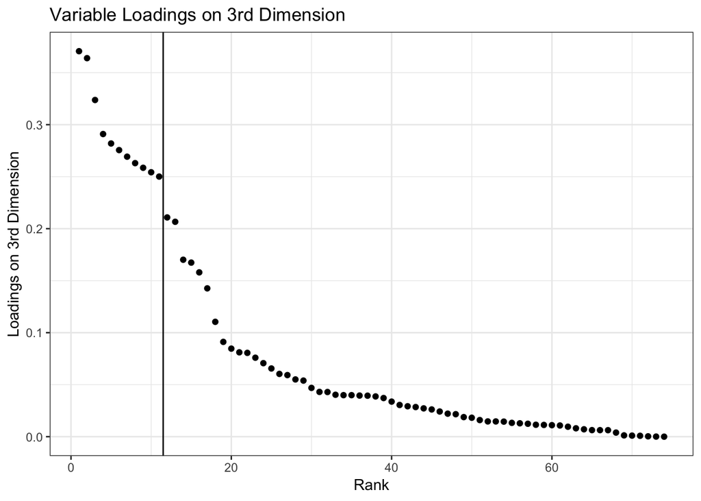

| variable | Dim.3 |
| --- | --- |
| apgar_1 | 0.2501051 |
| ph1 | 0.3639629 |
| patch | 0.2755701 |
| ecmo | 0.2909990 |
| nitric_oxide_therapy | 0.2692348 |
| dc_28 | 0.2585524 |
| day_28_oxygen | 0.3706637 |
| df_status_tube | 0.3237431 |
| hosp_2yr | 0.2542593 |
| hosp_5yr | 0.2630231 |
| ther5yr_any | 0.2819173 |

### Probabilistic graphical models

Gausian Mixture Models for K-means clustering. Three-centroid K-means using individual loadings on the three dimensions from FAMD analysis.

**Note that the K-means using factor loadings are quite different from K-means using original (imputed) dataset, the purpose of using the loadings is for interpretation**

```
## Iteration number 1
## Iteration number 2
```

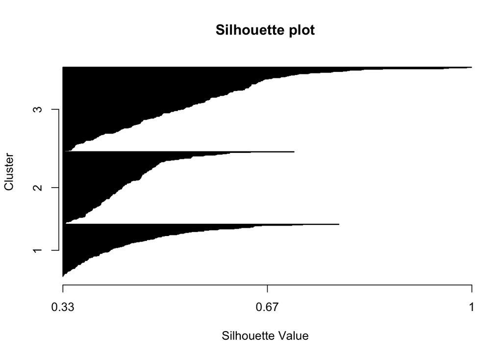

[interactive chart not shown]